# ANLY 506 EDA Assignment Fall 2018

Samed Jain

2019-02-11

### The Packages

```r
library(readr)
library(plyr)
library(data.table)
library(cvequality)
library(ggplot2)
library(ggbeeswarm)
library(ggthemes)
library(gridExtra)
library(cowplot)
```

## Describing Data

```r
rm(list = ls())
bikeVendors <- read_csv(file.choose())
bikeVendors<-data.frame(bikeVendors)
head(bikeVendors,10)
```

```
##                   model category1  category2    frame price
## 1           Bad Habit 1  Mountain      Trail Aluminum  3200
## 2           Bad Habit 2  Mountain      Trail Aluminum  2660
## 3   Beast of the East 1  Mountain      Trail Aluminum  2770
## 4   Beast of the East 2  Mountain      Trail Aluminum  2130
## 5   Beast of the East 3  Mountain      Trail Aluminum  1620
## 6     CAAD Disc Ultegra      Road Elite Road Aluminum  2660
## 7            CAAD12 105      Road Elite Road Aluminum  1680
## 8      CAAD12 Black Inc      Road Elite Road Aluminum  5860
## 9       CAAD12 Disc 105      Road Elite Road Aluminum  1950
## 10 CAAD12 Disc Dura Ace      Road Elite Road Aluminum  4260
##    Albuquerque.Cycles Ann.Arbor.Speed Austin.Cruisers Cincinnati.Speed
## 1         0.017482517     0.006644518     0.008130081      0.005115090
## 2         0.006993007     0.009966777     0.004065041      0.000000000
## 3         0.010489510     0.014950166     0.008130081      0.000000000
```

[output cut: 95 more lines]

The bike vendors dataset contains 35 different variables, and under each variable, there is a total of 97 observations. Some of the variables in the dataset include the bike model, the various categories that each bike highlighted falls under, as well as the price and other specifications.

Next on we check on the variable specifications, on whether there are numeric characters and whether there are string characters.

```r
str(bikeVendors)
```

```
## 'data.frame':    97 obs. of  35 variables:
##  $ model                       : chr  "Bad Habit 1" "Bad Habit 2" "Beast of the East 1" "Beast of the East 2" ...
##  $ category1                   : chr  "Mountain" "Mountain" "Mountain" "Mountain" ...
##  $ category2                   : chr  "Trail" "Trail" "Trail" "Trail" ...
##  $ frame                       : chr  "Aluminum" "Aluminum" "Aluminum" "Aluminum" ...
##  $ price                       : num  3200 2660 2770 2130 1620 2660 1680 5860 1950 4260 ...
##  $ Albuquerque.Cycles          : num  0.01748 0.00699 0.01049 0.01049 0.0035 ...
##  $ Ann.Arbor.Speed             : num  0.00664 0.00997 0.01495 0.00997 0.00332 ...
##  $ Austin.Cruisers             : num  0.00813 0.00407 0.00813 0.00813 0 ...
##  $ Cincinnati.Speed            : num  0.00512 0 0 0 0 ...
##  $ Columbus.Race.Equipment     : num  0.01015 0 0 0.00508 0.00254 ...
##  $ Dallas.Cycles               : num  0.01282 0.01709 0.00427 0.00427 0.00427 ...
##  $ Denver.Bike.Shop            : num  0.0117 0.0139 0.0183 0.0152 0.0169 ...
##  $ Detroit.Cycles              : num  0.00992 0.01587 0.0119 0.00595 0.0119 ...
##  $ Indianapolis.Velocipedes    : num  0.00627 0.00313 0.0094 0.0094 0 ...
```

[output cut: 21 more lines]

There are 4 string characters in the dataset, namely; The model,category 1, category 2 and the Frame of each bike in the dataset, the remaining 31 variables are all numeric. It is also worth noting that the dataset has no missing variables.

In the dataset, we proceed and check for any missing values in the respective dataset variables.

```r
complete.cases(bikeVendors)
```

```
##  [1] TRUE TRUE TRUE TRUE TRUE TRUE TRUE TRUE TRUE TRUE TRUE TRUE TRUE TRUE
## [15] TRUE TRUE TRUE TRUE TRUE TRUE TRUE TRUE TRUE TRUE TRUE TRUE TRUE TRUE
## [29] TRUE TRUE TRUE TRUE TRUE TRUE TRUE TRUE TRUE TRUE TRUE TRUE TRUE TRUE
## [43] TRUE TRUE TRUE TRUE TRUE TRUE TRUE TRUE TRUE TRUE TRUE TRUE TRUE TRUE
## [57] TRUE TRUE TRUE TRUE TRUE TRUE TRUE TRUE TRUE TRUE TRUE TRUE TRUE TRUE
## [71] TRUE TRUE TRUE TRUE TRUE TRUE TRUE TRUE TRUE TRUE TRUE TRUE TRUE TRUE
## [85] TRUE TRUE TRUE TRUE TRUE TRUE TRUE TRUE TRUE TRUE TRUE TRUE TRUE
```

## Exploring Data

In checking on the specific bike category that has a higher sale compared to the other, we do a background check on the frequency of each grouping, to identify the respective number of sales that each bike receives.

```r
count(bikeVendors$category1)
```

```
##          x freq
## 1 Mountain   51
## 2     Road   46
```

```r
count(bikeVendors$category2)
```

```
##                    x freq
## 1 Cross Country Race   19
## 2         Cyclocross    4
## 3         Elite Road   21
## 4     Endurance Road   16
## 5           Fat Bike    2
## 6      Over Mountain    8
## 7              Sport    9
## 8              Trail   13
## 9         Triathalon    5
```

```r
count(bikeVendors$frame)
```

```
##          x freq
## 1 Aluminum   40
## 2   Carbon   57
```

From the results, it is clear that the carbon frame has a higher popularity compared to the aluminium one.

```r
newMountain<-bikeVendors[bikeVendors$category1=='Mountain',]
sort(colSums(newMountain[,6:35]),decreasing = T)
```

```
##                  Tampa.29ers     Ithaca.Mountain.Climbers
##                    0.8009709                    0.7539557
##            Kansas.City.29ers Pittsburgh.Mountain.Machines
##                    0.7156439                    0.7082228
##             Denver.Bike.Shop                Dallas.Cycles
##                    0.7053455                    0.5170940
##             Portland.Bi.peds              Phoenix.Bi.peds
##                    0.5139751                    0.5088090
##           Los.Angeles.Cycles           Providence.Bi.peds
##                    0.5062893                    0.5036900
##        San.Antonio.Bike.Shop           Albuquerque.Cycles
##                    0.5000000                    0.5000000
##              New.York.Cycles               Detroit.Cycles
##                    0.4888889                    0.4801587
##       Philadelphia.Bike.Shop        Minneapolis.Bike.Shop
##                    0.4775510                    0.4733638
##      Columbus.Race.Equipment                Wichita.Speed
##                    0.3604061                    0.3451677
##             Las.Vegas.Cycles    Louisville.Race.Equipment
##                    0.3285256                    0.3240506
##           Nashville.Cruisers              Austin.Cruisers
##                    0.3092486                    0.2967480
##             Cincinnati.Speed         Miami.Race.Equipment
##                    0.2966752                    0.2907303
## Oklahoma.City.Race.Equipment     Indianapolis.Velocipedes
##                    0.2883117                    0.2852665
##       San.Francisco.Cruisers      New.Orleans.Velocipedes
##                    0.2807487                    0.2782609
##       Seattle.Race.Equipment              Ann.Arbor.Speed
##                    0.2421875                    0.2392027
```

In regards to the Mountain bike, Tampa 29ers has the most purchases, with a range of 0.8 in the frequency table. Next on we check on the most popular bikes around the Ann Arbor, Denver and San Francisco regions. In checking on the most popular bikes around this region, we first have to check on the highest frequency that falls under the three regions, which will aid in identifying the most popular bike.

```r
##For Ann Arbor
a<-bikeVendors[bikeVendors$Ann.Arbor.Speed==0.033222591,]
a$model
```

```
## [1] "Supersix Evo Hi-Mod Team" "Synapse Claris"
```

```r
##FOr Denver
b<-bikeVendors[bikeVendors$Denver.Bike.Shop==max(bikeVendors$Denver.Bike.Shop),]
b$model
```

```
## [1] "Catalyst 2"
```

```r
#For San Fransisco
c<-bikeVendors[bikeVendors$San.Francisco.Cruisers==max(bikeVendors$San.Francisco.Cruisers),]
c$model
```

```
## [1] "CAAD12 Red"
```

In Ann Arbor, the Supersix Evo Hi-Mod team and the Synapse Claris are the most popular bikes, while in Denver,the Catalyst 2 is the most popular bike. Finally, in San Fransisco, the most popular bike is the CAAD12 Red.

```r
clusters<-kmeans(bikeVendors[,6:35],5)
str(clusters)
```

```
## List of 9
##  $ cluster     : int [1:97] 1 1 1 1 1 4 4 5 4 5 ...
##  $ centers     : num [1:5, 1:30] 0.01154 0.00713 0.01678 0.01194 0.00905 ...
##   ..- attr(*, "dimnames")=List of 2
##   .. ..$ : chr [1:5] "1" "2" "3" "4" ...
##   .. ..$ : chr [1:30] "Albuquerque.Cycles" "Ann.Arbor.Speed" "Austin.Cruisers" "Cincinnati.Speed" ...
##  $ totss       : num 0.205
##  $ withinss    : num [1:5] 0.02214 0.02198 0.00621 0.04638 0.02061
##  $ tot.withinss: num 0.117
##  $ betweenss   : num 0.0881
##  $ size        : int [1:5] 20 26 5 29 17
##  $ iter        : int 3
##  $ ifault      : int 0
##  - attr(*, "class")= chr "kmeans"
```

Checking On the cluster algorith, we can make a conclusion that indeed clusters exist in the dataset. Next on we move on to check on whether there are variations in the dataset. We will use the Cvequality package check on whether there are variations in the bike vendors dataset. First, we would like to check whether there is any existing variation in category one, compared to the price of a specific bike. Below is a representation of the spread of the category one compared to the price

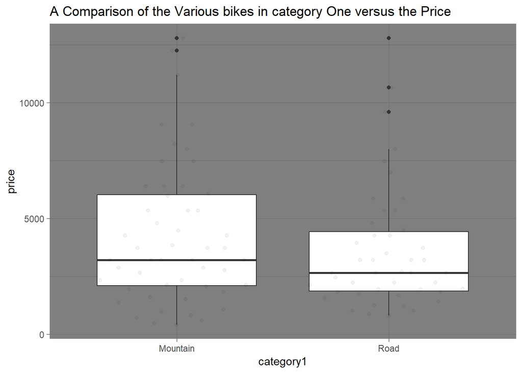

```r
ggplot(bikeVendors,aes(category1,price)) +
  geom_boxplot() +
  geom_quasirandom(alpha = 0.05) +
  theme_dark()+
  ggtitle("A Comparison of the Various bikes in category One versus the Price")
```

Looking at the plot, it is evident that the plot representation is quite similar, and would be difficult to prove on any existing variation, so we proceed further and use the asymptotic test to test on the variation between mountain and road bikes.

```r
bike_price_by_category1_test <- with(bikeVendors,
       asymptotic_test(price,category1))
bike_price_by_category1_test
```

```
## $D_AD
## [1] 0.01913193
##
## $p_value
## [1] 0.8899889
```

From the test, it is evident that the coefficients of variations in the mountain and Road bikes are similar and therefore there is no difference in the price variation in the two. We repeat the same procedure for category 2 to ascertain whether the same holds.

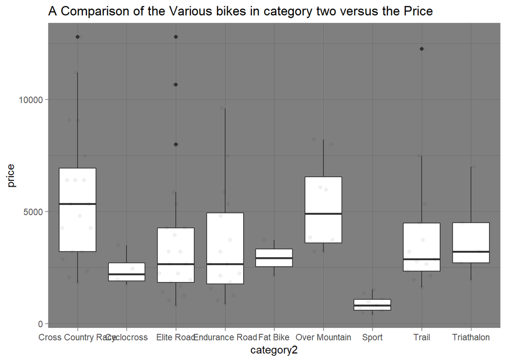

```r
ggplot(bikeVendors,aes(category2,price)) +
  geom_boxplot() +
  geom_quasirandom(alpha = 0.05) +
  theme_dark()+
  ggtitle("A Comparison of the Various bikes in category two versus the Price")
```

There seems to be a variation in the prices of bikes on category two, where sport bikes are relatively lower than the other groupings. To ascertain this, we check on the asymptotic test results.

```r
bike_price_by_category2_test <- with(bikeVendors,
       asymptotic_test(price,category2))
bike_price_by_category2_test
```

```
## $D_AD
## [1] 6.111201
##
## $p_value
## [1] 0.6347771
```

We further proceed to compare on the bikes sold on these respective regions, in regards to the different categories as well as the price grouping.

```r
#For The West Coast.
a<-ggplot(bikeVendors,aes(category1,Los.Angeles.Cycles)) +
  geom_boxplot() +
  geom_quasirandom(alpha = 0.05) +theme_dark()
b<-ggplot(bikeVendors,aes(category1,Portland.Bi.peds)) +
  geom_boxplot()+geom_quasirandom(alpha = 0.05) +theme_dark()

c<- ggplot(bikeVendors,aes(category1,San.Francisco.Cruisers)) +
  geom_boxplot()+geom_quasirandom(alpha = 0.05)+theme_dark()

d<- ggplot(bikeVendors,aes(category1,Seattle.Race.Equipment)) +
  geom_boxplot()+geom_quasirandom(alpha = 0.05)+theme_dark()

a = a + theme(axis.text.x = element_text(angle = 90, hjust = 1, vjust = 0.5))
b = b + theme(axis.text.x = element_text(angle = 90, hjust = 1, vjust = 0.5))
c = c + theme(axis.text.x = element_text(angle = 90, hjust = 1, vjust = 0.5))
d = d + theme(axis.text.x = element_text(angle = 90, hjust = 1, vjust = 0.5))
```

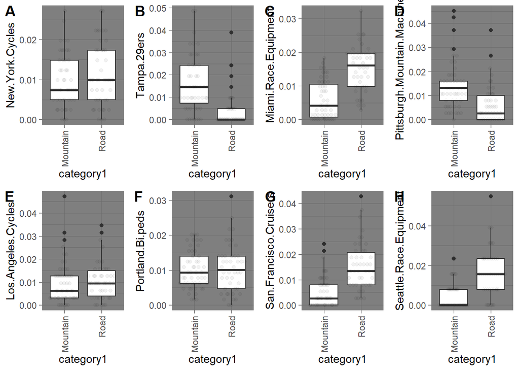

```r
aaa<-ggplot(bikeVendors,aes(category1,New.York.Cycles)) +
  geom_boxplot() +
  geom_quasirandom(alpha = 0.05) +theme_dark()
bbb<-ggplot(bikeVendors,aes(category1,Tampa.29ers)) +
  geom_boxplot()+geom_quasirandom(alpha = 0.05) +theme_dark()

ccc<- ggplot(bikeVendors,aes(category1,Miami.Race.Equipment)) +
  geom_boxplot()+geom_quasirandom(alpha = 0.05)+theme_dark()

ddd<- ggplot(bikeVendors,aes(category1,Pittsburgh.Mountain.Machines)) +
  geom_boxplot()+geom_quasirandom(alpha = 0.05)+theme_dark()

aaa = aaa + theme(axis.text.x = element_text(angle = 90, hjust = 1, vjust = 0.5))
bbb = bbb + theme(axis.text.x = element_text(angle = 90, hjust = 1, vjust = 0.5))
ccc = ccc + theme(axis.text.x = element_text(angle = 90, hjust = 1, vjust = 0.5))
ddd = ddd + theme(axis.text.x = element_text(angle = 90, hjust = 1, vjust = 0.5))

plot_grid(aaa,bbb,ccc,ddd,a,b,c,d, ncol=4, labels = "AUTO")
```

Next on we plot the bike sales for the two in regards to category 2 of the respective bikes

```r
aaaa<-ggplot(bikeVendors,aes(category2,New.York.Cycles)) +
  geom_boxplot() +
  geom_quasirandom(alpha = 0.05) +theme_dark()
bbbb<-ggplot(bikeVendors,aes(category2,Tampa.29ers)) +
  geom_boxplot()+geom_quasirandom(alpha = 0.05) +theme_dark()

cccc<- ggplot(bikeVendors,aes(category2,Miami.Race.Equipment)) +
  geom_boxplot()+geom_quasirandom(alpha = 0.05)+theme_dark()

dddd<- ggplot(bikeVendors,aes(category2,Pittsburgh.Mountain.Machines)) +
  geom_boxplot()+geom_quasirandom(alpha = 0.05)+theme_dark()

aaaa = aaaa + theme(axis.text.x = element_text(angle = 90, hjust = 1, vjust = 0.5))
bbbb= bbbb + theme(axis.text.x = element_text(angle = 90, hjust = 1, vjust = 0.5))
cccc = cccc + theme(axis.text.x = element_text(angle = 90, hjust = 1, vjust = 0.5))
dddd = dddd + theme(axis.text.x = element_text(angle = 90, hjust = 1, vjust = 0.5))
```

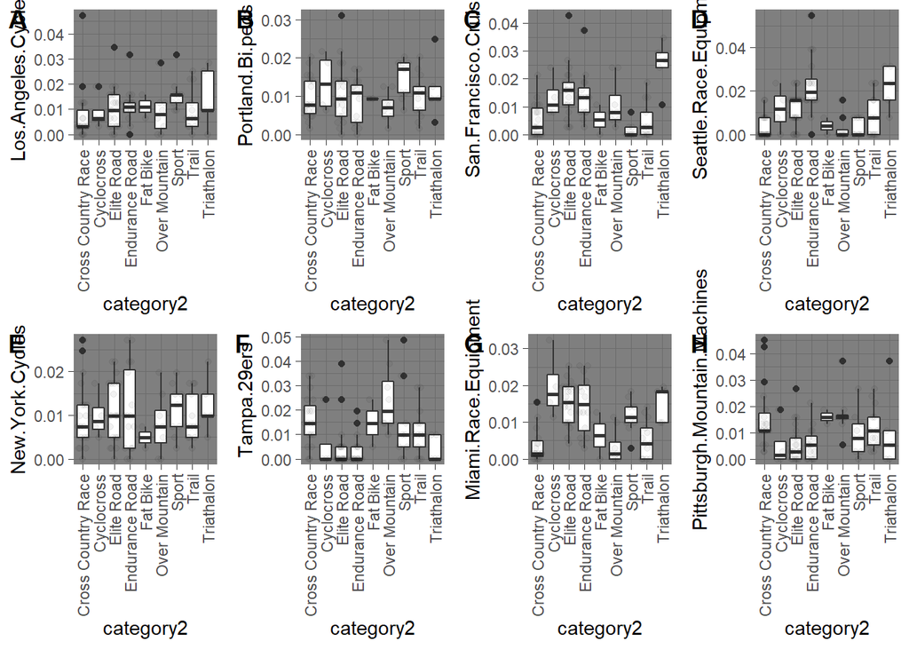

```r
##FOr Category 2
aa<-ggplot(bikeVendors,aes(category2,Los.Angeles.Cycles)) +
  geom_boxplot() +
  geom_quasirandom(alpha = 0.05) +theme_dark()
bb<-ggplot(bikeVendors,aes(category2,Portland.Bi.peds)) +
  geom_boxplot()+geom_quasirandom(alpha = 0.05) +theme_dark()

cc<- ggplot(bikeVendors,aes(category2,San.Francisco.Cruisers)) +
  geom_boxplot()+geom_quasirandom(alpha = 0.05)+theme_dark()

dd<- ggplot(bikeVendors,aes(category2,Seattle.Race.Equipment)) +
  geom_boxplot()+geom_quasirandom(alpha = 0.05)+theme_dark()

aa = aa + theme(axis.text.x = element_text(angle = 90, hjust = 1, vjust = 0.5))
bb = bb + theme(axis.text.x = element_text(angle = 90, hjust = 1, vjust = 0.5))
cc = cc + theme(axis.text.x = element_text(angle = 90, hjust = 1, vjust = 0.5))
dd = dd + theme(axis.text.x = element_text(angle = 90, hjust = 1, vjust = 0.5))

plot_grid(aa,bb,cc,dd,aaaa,bbbb,cccc,dddd, ncol=4,labels = "AUTO")
```

Next on we Check on the two regions based on category two of bike Sales. In the grouping, It is evident that San Francisco tops the group in regards to the Triathalon bike sale, with most sales being observed in the city, whilst The least sales on the city are in terms of the cross country and sport bikes. Also, Seattle has a weak sale in regards to the Over mountain bikes. On the East coast, The most sales observed are on the Cyclocross, mostly sold in Miami, while the least sale is on Pittsburgh, in regards to the Elite road, Endurance road and the Triathalon bikes.

Next on we check on the most zero bikes sales in the cities.

```r
res_Zeros <- colSums(bikeVendors[,6:35]==0)
res_Zeros
```

```
##           Albuquerque.Cycles              Ann.Arbor.Speed
##                           13                           13
##              Austin.Cruisers             Cincinnati.Speed
##                           22                           15
##      Columbus.Race.Equipment                Dallas.Cycles
##                           12                           20
##             Denver.Bike.Shop               Detroit.Cycles
##                            0                            5
##     Indianapolis.Velocipedes     Ithaca.Mountain.Climbers
##                           23                            9
##            Kansas.City.29ers             Las.Vegas.Cycles
##                            0                           14
##           Los.Angeles.Cycles    Louisville.Race.Equipment
##                           11                           20
##         Miami.Race.Equipment        Minneapolis.Bike.Shop
##                           13                            2
##           Nashville.Cruisers      New.Orleans.Velocipedes
##                           15                           13
##              New.York.Cycles Oklahoma.City.Race.Equipment
##                            6                            9
##       Philadelphia.Bike.Shop              Phoenix.Bi.peds
##                           15                            0
## Pittsburgh.Mountain.Machines             Portland.Bi.peds
##                           16                            2
##           Providence.Bi.peds        San.Antonio.Bike.Shop
##                            1                           21
##       San.Francisco.Cruisers       Seattle.Race.Equipment
##                           19                           37
##                  Tampa.29ers                Wichita.Speed
##                           36                           15
```

```r
sort(res_Zeros,decreasing = T)
```

```
##       Seattle.Race.Equipment                  Tampa.29ers
##                           37                           36
##     Indianapolis.Velocipedes              Austin.Cruisers
##                           23                           22
##        San.Antonio.Bike.Shop                Dallas.Cycles
##                           21                           20
##    Louisville.Race.Equipment       San.Francisco.Cruisers
##                           20                           19
## Pittsburgh.Mountain.Machines             Cincinnati.Speed
##                           16                           15
##           Nashville.Cruisers       Philadelphia.Bike.Shop
##                           15                           15
##                Wichita.Speed             Las.Vegas.Cycles
##                           15                           14
##           Albuquerque.Cycles              Ann.Arbor.Speed
##                           13                           13
##         Miami.Race.Equipment      New.Orleans.Velocipedes
##                           13                           13
##      Columbus.Race.Equipment           Los.Angeles.Cycles
##                           12                           11
##     Ithaca.Mountain.Climbers Oklahoma.City.Race.Equipment
##                            9                            9
##              New.York.Cycles               Detroit.Cycles
##                            6                            5
##        Minneapolis.Bike.Shop             Portland.Bi.peds
##                            2                            2
##           Providence.Bi.peds             Denver.Bike.Shop
##                            1                            0
##            Kansas.City.29ers              Phoenix.Bi.peds
##                            0                            0
```